# Test different clustering methods

Ulrik Stervbo

2017-01-25

Here I document different methods for identifying the bead groups in the forward/side scatter.

## Artificial test data

Load the **legendplexr** and set seed before we create some artificial data

```r
library(legendplexr)
set.seed(12345)
```

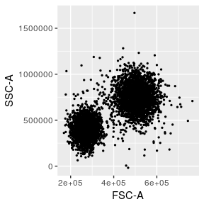

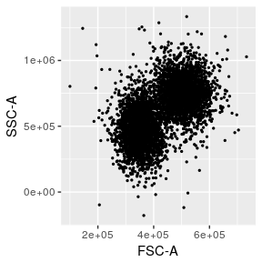

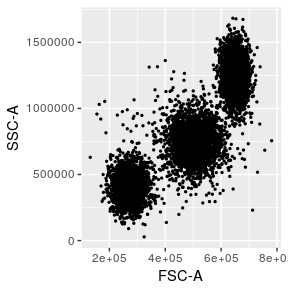

```r
library(purrr)
library(dplyr)
create_test_data <- function(n_beads = 2500, n_noise = 2500/10,
                             x_range_bead = list(c(2.1e5L, 3.33e5L), c(4.1e5L, 6e5L)),
                             y_range_bead = list(c(2.1e5L, 6e5L), c(5e5L, 1e6L)),
                             x_range_noise = c(2e5L, 7e5L),
                             y_range_noise = c(2e5L, 1.2e6L)){

  # .range <- c(2.1e5L, 3.33e5L)
  .generate_data <- function(.range, .n_points){
    # runif(.n_points, .range[1], .range[2])
    # seq.int(min(.range), max(.range)) %>%
    # sample(size = .n_points)
    sample_mean <- median(.range)
    sample_sd <- (max(.range) - min(.range))/4
    rnorm(.n_points, mean = sample_mean, sd = sample_sd)
    # rgamma(.n_points, shape = min(.range), rate = sample_sd) %>% log
  }

  beads_x <- lapply(x_range_bead, .generate_data, .n_points = n_beads) %>% unlist
  beads_y <- lapply(y_range_bead, .generate_data, .n_points = n_beads) %>% unlist

  noise_x <- .generate_data(x_range_noise, .n_points = n_noise) %>% unlist
  noise_y <- .generate_data(y_range_noise, .n_points = n_noise) %>% unlist

  data_frame(`FSC-A` = c(beads_x, noise_x), `SSC-A` = c(beads_y, noise_y))
}

test_data_1 <- create_test_data()
test_data_2 <- create_test_data(x_range_bead = list(c(2.7e5L, 4.3e5L), c(4.1e5L, 6e5L)),
                                y_range_bead = list(c(1.8e5L, 7.5e5L), c(5e5L, 1e6L)))

test_data_3<- create_test_data(x_range_bead = list(c(2.1e5L, 3.33e5L), c(4.1e5L, 6e5L), c(6.0e5L, 7.0e5L)),
                                y_range_bead = list(c(2.1e5L, 6e5L), c(5e5L, 1e6L), c(1e6L, 1.5e6L)))

test_data <- list(list(.data = test_data_1,
                       .n_clusters = 2),
                  list(.data = test_data_2,
                       .n_clusters = 2),
                  list(.data = test_data_3,
                       .n_clusters = 3))

rm(test_data_1, test_data_2, test_data_3)

test_data %>% map(function(.x){plot_facs(.x$.data)}) %>% walk(print)
```

### Conclusion

The data below demonstrates that the better candidates are

- `fpc::dbscan()`
- `dbscan::dbscan()`
- `fpc::trimkmeansCBI()` or `trimcluster::trimkmeans()` which is the one behind the scenes

## Kmeans

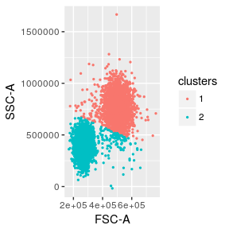

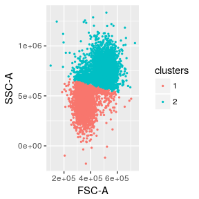

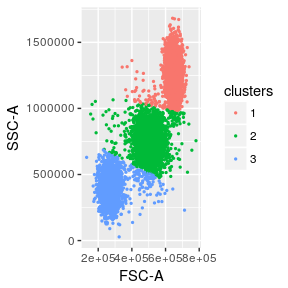

```r
test_kmeans <- function(.cur_test_set){
  .data <- .cur_test_set$.data
  .n_clusters <- .cur_test_set$.n_clusters
  kmeans_res <- kmeans(.data, .n_clusters)
  .data$clusters <- as.character(kmeans_res$cluster)

  plot_facs(.data, .beads = "clusters")

}

test_data %>% map(test_kmeans) %>% walk(print)
```

Kmeans clustering is suboptimal because of the problems with clusters in close vincinity, and becaue it does not remove background.

## DBscan

DBSCAN requires a bit of fiddling to get the values right for the populations, but since the flow cytometer *should not* drift during the acquisition, they should work for the entire experiment.

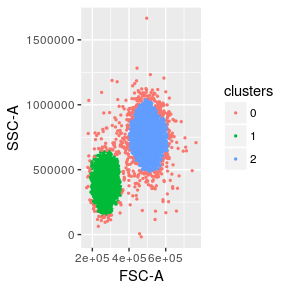

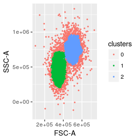

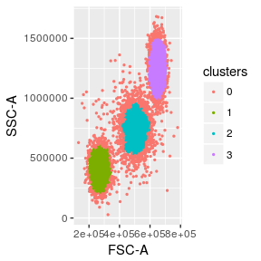

```r
library(fpc)

test_dbscan <- function(.cur_test_set, .param){
.eps = .param["eps"]
.minPts = .param["minPts"]

.data <- .cur_test_set$.data

dbscan_res <- fpc::dbscan(.data[, c(1, 2)], eps = .eps, MinPts = .minPts, scale = TRUE)
.data$clusters <- as.character(dbscan_res$cluster)

plot_facs(.data, .beads = "clusters")
}

db_param <- list(set_1 = c(eps = 0.2, minPts = 50),
                 set_2 = c(eps = 0.2, minPts = 50),
                 set_3 = c(eps = 0.1, minPts = 50))

test_data %>% map2(.y = db_param, test_dbscan) %>% walk(print)
```

### Package dbscan

The above `dbscan()` from **fpc** seems a little slow, so `dbscan()` form **dbscan** is also tested:

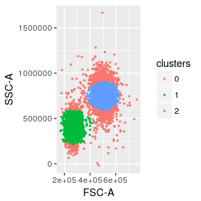

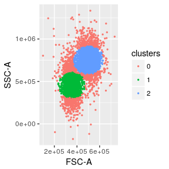

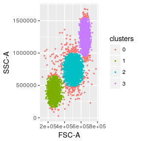

```r
library(dbscan)

test_dbscan <- function(.cur_test_set, .param){
.eps = .param["eps"]
.minPts = .param["minPts"]

.data <- .cur_test_set$.data

dbscan_res <- dbscan::dbscan(.data[, c(1, 2)], eps = .eps, minPts = .minPts)
.data$clusters <- as.character(dbscan_res$cluster)

plot_facs(.data, .beads = "clusters")
}

db_param <- list(set_1 = c(eps = 9e4, minPts = 1000),
                 set_2 = c(eps = 9e4, minPts = 1000),
                 set_3 = c(eps = 5e4, minPts = 100))

test_data %>% map2(.y = db_param, test_dbscan) %>% walk(print)
```

The parameters needed varies considerably between the two packages. The implementation in **fpc** might be the better, dispite the apparent speed deficiet, because it seems to follow the shape of the bead distributions better than the one in the **dbscan** package.

The optimal function, is one that would yield a similar result as the `dbscan()` using just the number of groups.

## Packege fpc

The package **fpc** provides several cluster functions and wrappers around other functions. Here we look at potential usefull methods.

### `kmeansCBI()`

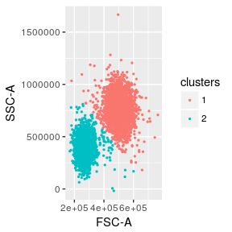

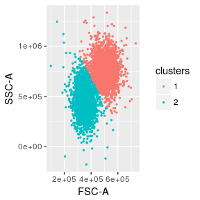

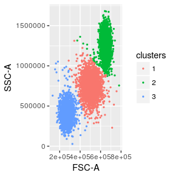

```r
library(fpc)

test_fpcCBI <- function(.cur_test_set){
  .data <- .cur_test_set$.data
  .n_clusters <- .cur_test_set$.n_clusters

  clust_res <- kmeansCBI(.data[, c(1, 2)], k = .n_clusters, scaling = TRUE)
  .data$clusters <- as.character(clust_res$result$cluster)

  plot_facs(.data, .beads = "clusters")
}

test_data %>% map(test_fpcCBI) %>% walk(print)
```

### `hclustCBI()`

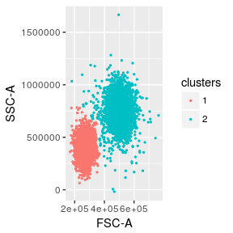

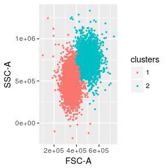

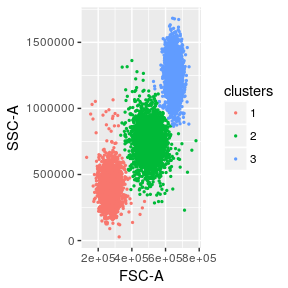

```r
library(fpc)

test_fpcCBI <- function(.cur_test_set){
  .data <- .cur_test_set$.data
  .n_clusters <- .cur_test_set$.n_clusters

  clust_res <- hclustCBI(.data[, c(1, 2)], k = .n_clusters, scaling = TRUE, method = "ward.D2", noisecut = 100)
  .data$clusters <- as.character(clust_res$partition)

  plot_facs(.data, .beads = "clusters")
}

test_data %>% map(test_fpcCBI) %>% walk(print)
```

This method seems to do a good job, with the exception of the noise which is not removed.

### `claraCBI()`

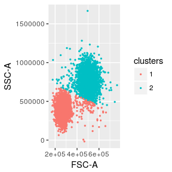

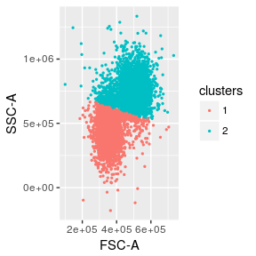

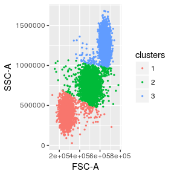

```r
library(fpc)

test_fpcCBI <- function(.cur_test_set){
  .data <- .cur_test_set$.data
  .n_clusters <- .cur_test_set$.n_clusters

  clust_res <- claraCBI(.data[, c(1, 2)], k = .n_clusters)
  .data$clusters <- as.character(clust_res$result$clustering)

  plot_facs(.data, .beads = "clusters")
}

test_data %>% map(test_fpcCBI) %>% walk(print)
```

### `pamkCBI()`

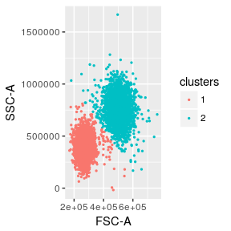

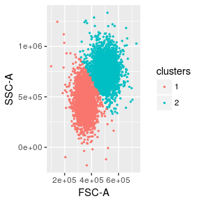

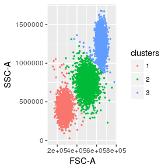

```r
library(fpc)

test_fpcCBI <- function(.cur_test_set){
  .data <- .cur_test_set$.data
  .n_clusters <- .cur_test_set$.n_clusters

  clust_res <- pamkCBI(.data[, c(1, 2)], k = .n_clusters)
  .data$clusters <- as.character(clust_res$result$pamobject$clustering)

  plot_facs(.data, .beads = "clusters")
}

test_data %>% map(test_fpcCBI) %>% walk(print)
```

### `trimkmeansCBI()`

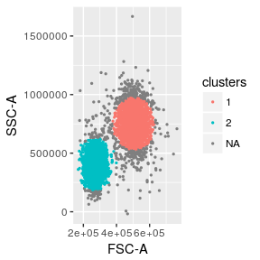

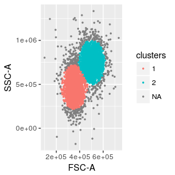

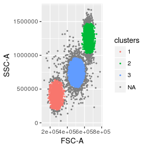

```r
library(fpc)

test_fpcCBI <- function(.cur_test_set){
  .data <- .cur_test_set$.data
  .n_clusters <- .cur_test_set$.n_clusters

  clust_res <- trimkmeansCBI(.data[, c(1, 2)], k = .n_clusters, scaling = TRUE, runs = 1)
  .data$clusters <- as.character(clust_res$partition)
  .data$clusters <- ifelse(.data$clusters > .n_clusters, NA, .data$clusters)

  plot_facs(.data, .beads = "clusters")
}

test_data %>% map(test_fpcCBI) %>% walk(print)
```

This function `trimkmeansCBI()` seems to do a good job, using just the number of clusters. It appears to work well with `runs = 1`. In case it is needed, maybe other ways of calculating the start points can be made. The default `runs = 100` makes the function *so* slow, that it is hardly practical.

### `mergenormCBI()`

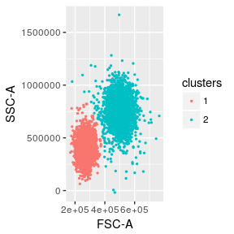

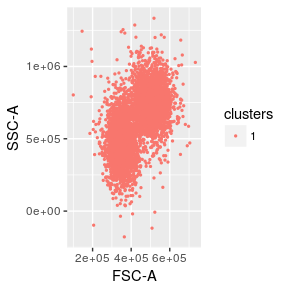

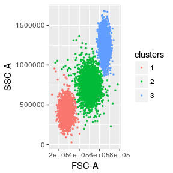

```r
library(fpc)

test_fpcCBI <- function(.cur_test_set){
  .data <- .cur_test_set$.data
  .n_clusters <- .cur_test_set$.n_clusters

  clust_res <- mergenormCBI(.data[, c(1, 2)], k = .n_clusters)
  .data$clusters <- as.character(clust_res$result$clustering)

  plot_facs(.data, .beads = "clusters")
}

test_data %>% map(test_fpcCBI) %>% walk(print)
```